# R Notebook

Ashish Kumar

**Principles of Data Visualization and Introduction to ggplot2**

I have provided you with data about the 5,000 fastest growing companies in the US, as compiled by Inc. magazine. lets read this in:

```r
inc <- read.csv("https://raw.githubusercontent.com/charleyferrari/CUNY_DATA_608/master/module1/Data/inc5000_data.csv", header= TRUE)
```

And lets preview this data:

```r
head(inc)
```

|  | Rank | Name | Growth_Rate | Revenue | Industry | Employees | City | State |
| --- | --- | --- | --- | --- | --- | --- | --- | --- |
| 1 | 1 | Fuhu | 421.48 | 1.179e+08 | Consumer Products & Services | 104 | El Segundo | CA |
| 2 | 2 | FederalConference.com | 248.31 | 4.960e+07 | Government Services | 51 | Dumfries | VA |
| 3 | 3 | The HCI Group | 245.45 | 2.550e+07 | Health | 132 | Jacksonville | FL |
| 4 | 4 | Bridger | 233.08 | 1.900e+09 | Energy | 50 | Addison | TX |
| 5 | 5 | DataXu | 213.37 | 8.700e+07 | Advertising & Marketing | 220 | Boston | MA |
| 6 | 6 | MileStone Community Builders | 179.38 | 4.570e+07 | Real Estate | 63 | Austin | TX |

```r
NA
```

```r
summary(inc)
```

```
      Rank                          Name       Growth_Rate         Revenue                                  Industry      Employees                  City
 Min.   :   1   (Add)ventures         :   1   Min.   :  0.340   Min.   :2.000e+06   IT Services                 : 733   Min.   :    1.0   New York     : 160
 1st Qu.:1252   @Properties           :   1   1st Qu.:  0.770   1st Qu.:5.100e+06   Business Products & Services: 482   1st Qu.:   25.0   Chicago      :  90
 Median :2502   1-Stop Translation USA:   1   Median :  1.420   Median :1.090e+07   Advertising & Marketing     : 471   Median :   53.0   Austin       :  88
 Mean   :2502   110 Consulting        :   1   Mean   :  4.612   Mean   :4.822e+07   Health                      : 355   Mean   :  232.7   Houston      :  76
 3rd Qu.:3751   11thStreetCoffee.com  :   1   3rd Qu.:  3.290   3rd Qu.:2.860e+07   Software                    : 342   3rd Qu.:  132.0   San Francisco:  75
 Max.   :5000   123 Exteriors         :   1   Max.   :421.480   Max.   :1.010e+10   Financial Services          : 260   Max.   :66803.0   Atlanta      :  74
                (Other)               :4995                                         (Other)                     :2358   NA's   :12        (Other)      :4438
     State
 CA     : 701
 TX     : 387
 NY     : 311
 VA     : 283
 FL     : 282
 IL     : 273
 (Other):2764
```

Think a bit on what these summaries mean. Use the space below to add some more relevant non-visual exploratory information you think helps you understand this data:

```r
# Insert your code here, create more chunks as necessary
dim(inc)
```

```
[1] 5001    8
```

```r
suppressMessages(suppressWarnings(library(tidyverse)))
suppressMessages(suppressWarnings(library(ggplot2)))
suppressMessages(suppressWarnings(library("RColorBrewer")))
```

```r
#Lets see the Standard Deviaition for Numberical fields Growth/Revenue and Employees

print(paste("SD for Growth Rate ",sd(inc$Growth_Rate)))
```

```
[1] "SD for Growth Rate  14.1236917640676"
```

```r
print(paste("SD for Revenue ",sd(inc$Revenue)))
```

```
[1] "SD for Revenue  240542281.135874"
```

```r
print(paste("SD for Employees",sd(inc$Employees, na.rm = TRUE))) # Some companies have missing employee counts
```

```
[1] "SD for Employees 1353.12794924661"
```

[figure not shown]

```r
plot(inc$Rank, inc$Growth_Rate,col="blue")
```

```r
print(paste("Looks Like only Higher ranked Companies have good growth rates"))
```

```
[1] "Looks Like only Higher ranked Companies have good growth rates"
```

## Question 1

Create a graph that shows the distribution of companies in the dataset by State (ie how many are in each state). There are a lot of States, so consider which axis you should use. This visualization is ultimately going to be consumed on a ‘portrait’ oriented screen (ie taller than wide), which should further guide your layout choices.

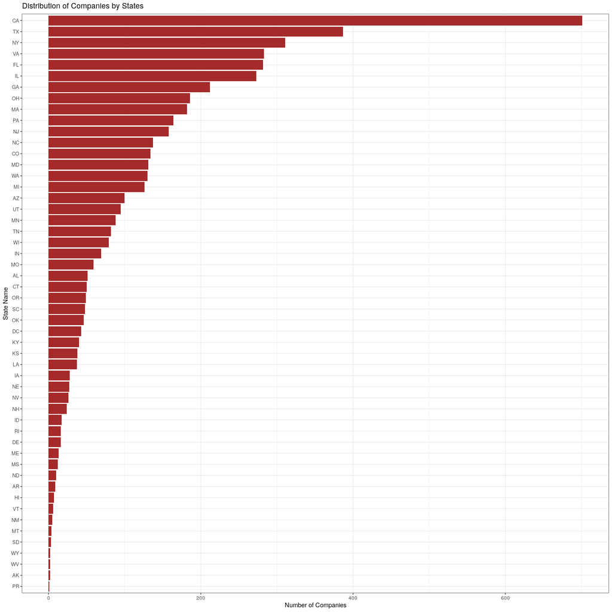

```r
# Answer Question 1 here
# Create Summary of states dataframe and sort by companies
states <- inc %>%
  group_by(State) %>%
  count() %>%
  rename(count = n) %>%
  arrange(desc(count))
# plot
stplot <- ggplot(states, aes(x = reorder(State, count), y = count))
stplot <- stplot + geom_bar(stat = "identity", fill = 'Brown') + coord_flip()
stplot <- stplot + ggtitle("Distribution of Companies by States")
stplot <- stplot + labs(x = "State Name", y = "Number of Companies")
stplot <- stplot + theme(plot.title = element_text(hjust = 0.5), plot.subtitle = element_text(hjust = 0.5)) + theme_bw()
stplot
```

```r
print("California is the state with most distribution of companies")
```

```
[1] "California is the state with most distribution of companies"
```

## Quesiton 2

Lets dig in on the state with the 3rd most companies in the data set. Imagine you work for the state and are interested in how many people are employed by companies in different industries. Create a plot that shows the average and/or median employment by industry for companies in this state (only use cases with full data, use R’s `complete.cases()` function.) In addition to this, your graph should show how variable the ranges are, and you should deal with outliers.

```r
# Answer Question 2 here
# find state with third most companies (3rd row b/c already ordered desc)
third_state <- states[3,"State"]
third_state
```

| State |
| --- |
| NY |

[figure not shown]

```r
# Get complete cases and 3rd ranked state only
third_state_data <- inc[complete.cases(inc),] %>%
  inner_join(third_state, by = "State")
# Mean employment by industry
mean_emp <- aggregate(Employees ~ Industry, third_state_data, mean)
# Maximum average employee no.
maxmean <- max(mean_emp$Employees)
# plot data
emp_plot<- ggplot(third_state_data, aes(x = reorder(Industry,Employees,mean), y = Employees))
emp_plot<- emp_plot+ geom_boxplot(outlier.shape = NA, show.legend=F) + coord_flip()
emp_plot<- emp_plot+ labs(x = "industry", y = "employees", title="Mean Employment Size by Industry")
emp_plot<- emp_plot+ geom_point(data = mean_emp, aes(x=Industry, y=Employees), color='darkblue', size = 2)
emp_plot<- emp_plot+ theme(plot.title = element_text(hjust = 0.5), plot.subtitle = element_text(hjust = 0.5))

emp_plot<- emp_plot+  scale_y_continuous(limits = c(0,maxmean), breaks = seq(0, maxmean, 500)) + theme_bw()
emp_plot
```

The average employee count in the Business Products & Services industry are many times greater than the other industries.

For Such a big skew and outliers we can use log scale

[figure not shown]

```r
emp_plot <- emp_plot + scale_y_log10(limits = c(1, maxmean))
emp_plot <- emp_plot + labs(caption = "(grid line spacing on log scale)")
emp_plot <- emp_plot + theme(plot.caption = element_text(size = 8))
emp_plot
```

## Question 3

Now imagine you work for an investor and want to see which industries generate the most revenue per employee. Create a chart that makes this information clear. Once again, the distribution per industry should be shown.

```r
# Answer Question 3 here

#filter out incomplete cases

revenue_data <- inc[complete.cases(inc),] %>%
  group_by(Industry) %>%
  summarise(org_count = n(),Revenue = sum(Revenue),Employees= sum(Employees)) %>%
  mutate(rev = Revenue / Employees )

str(revenue_data)
```

```
tibble [25 × 5] (S3: tbl_df/tbl/data.frame)
 $ Industry : Factor w/ 25 levels "Advertising & Marketing",..: 1 2 3 4 5 6 7 8 9 10 ...
 $ org_count: int [1:25] 471 480 44 187 203 83 109 74 51 260 ...
 $ Revenue  : num [1:25] 7.78e+09 2.63e+10 1.19e+10 1.32e+10 1.50e+10 ...
 $ Employees: int [1:25] 39731 117357 9714 29099 45464 7685 26437 20435 10155 47693 ...
 $ rev      : num [1:25] 195943 224494 1223564 452741 328972 ...
```

```r
head(revenue_data)
```

| Industry | org_count | Revenue | Employees | rev |
| --- | --- | --- | --- | --- |
| Advertising & Marketing | 471 | 7785000000 | 39731 | 195942.7 |
| Business Products & Services | 480 | 26345900000 | 117357 | 224493.6 |
| Computer Hardware | 44 | 11885700000 | 9714 | 1223563.9 |
| Construction | 187 | 13174300000 | 29099 | 452740.6 |
| Consumer Products & Services | 203 | 14956400000 | 45464 | 328972.4 |
| Education | 83 | 1139300000 | 7685 | 148249.8 |

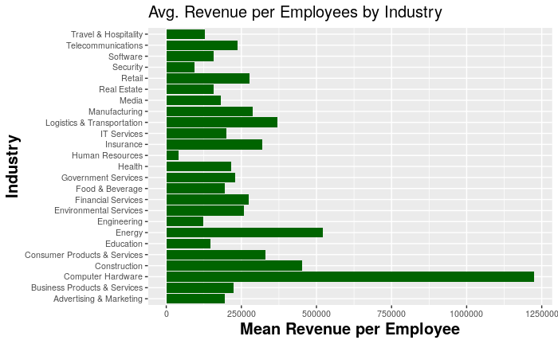

```r
# Plot average revenue by industry
reven_plt<- ggplot(revenue_data) +  geom_bar(aes(Industry, rev, fill = Industry), stat = "summary", fun.y = "mean", fill="darkgreen")
reven_plt<- reven_plt+ coord_flip()
reven_plt<- reven_plt+ theme(legend.position="none")
reven_plt<- reven_plt+ theme(text = element_text(size=10), axis.title=element_text(size=15,face="bold"))
reven_plt<- reven_plt+ labs(title = "Avg. Revenue per Employees by Industry", x= "Industry", y= "Mean Revenue per Employee")
reven_plt<- reven_plt+ theme(plot.title = element_text(size=15))
reven_plt
```

```r
print("Computer Hardware seems to the industry with highest employee revenue on Average")
```

```
[1] "Computer Hardware seems to the industry with highest employee revenue on Average"
```